# Exercise 4_1: Simple Map

Advanced Geospatial Data Processing for Social Scientists

Author

Dennis Abel & Stefan Jünger

### Exercises

We are now focussing on creating a first map based on raster data in `ggplot`. We will work with population data in the US.

**🏋 Exercise 1**

Load the WorldPop file for the USA in 2020 (`./data/usa_ppp_2020_1km_Aggregated.tif`). Create a simple plot with `terra::plot()` to inspect the data.

**🏋 Exercise 2**

We want to focus on the 48 contiguous States and exclude Alaska, Hawaii as well as overseas territories. To do that, please:

- load a US States shapefile with the tigris package,
- filter it to the 48 contiguous states,
- and plot the shapefile to cross-check your progress.

**💡 Tip**

We haven’t worked with `tigris` before. Below you find the code to load and select the relevant US states.

```r
# install.packages("tigris")
library(tigris)

US_states <- states() |>
  dplyr::filter(!STUSPS %in% c("AK", "AS", "GU", "HI", "MP", "PR", "VI"))
```

**🏋 Exercise 3**

We now want to crop the raster-file on the basis of the US states bounding box:

- Create a bounding box based on your shapefile,
- Reproject this bbox to the CRS of the raster file,
- Then crop the raster file on based on the bbox.

**💡 Tip**

You will need three `sf`-commands to prepare your bbox: `st_bbox()` to create the bbox, `st_as_sfc()` to transform it into an `sf`-object and `st_transform()` to reproject it to the CRS of your raster file. The code below shows the entire pipe for these steps.

```r
bbox <- sf::st_bbox(US_states) |>
  sf::st_as_sfc() |>
  sf::st_transform(crs = terra::crs(USA_pop_2020))
```

**🏋 Exercise 4**

Inspect the attributes of your raster file. The CRS is currently in WGS84. Is that suitable for a plot of the US territory? Alternatively, “NAD83 / Conus Albers” is often used for data analysis and presentation of the 48 contiguous US states. It is an equal-area projection and minimizes distortion across the US territory.

- Search for the EPSG of “NAD83 / Conus Albers” on https://spatialreference.org/ref/,
- Reproject the map and your shapefile accordingly.

**🏋 Exercise 5**

Now we can plot the population data together with the shapefile for the US states. Adjust color schemes accordingly and add labels.

**💡 Tip**

Unfortunately, our data is right-skewed and contains a few outliers with high population numbers per grid cell. This is a challenge for our color-coding. When working with `scale_fill_distiller` or `scale_fill_viridis_c` to adjust your color scheme, you could utilize the arguments `limits` and `oob = scales::squish` to account for that.

```r
ggplot()+
  ... +
  scale_fill_distiller(...,
                       limits = c(0, 1000),
                       oob = scales::squish
                       ) +
  ...
```

### Solutions

**✅ Solution 1**

```r
# load libraries
library(dplyr)
library(sf)
library(ggplot2)
library(terra)
library(tidyterra)

# Load the data
USA_pop_2020 <- terra::rast("./data/usa_ppp_2020_1km_Aggregated.tif")

# Inspect it
terra::plot(USA_pop_2020)
```

```
terra 1.8.29
```

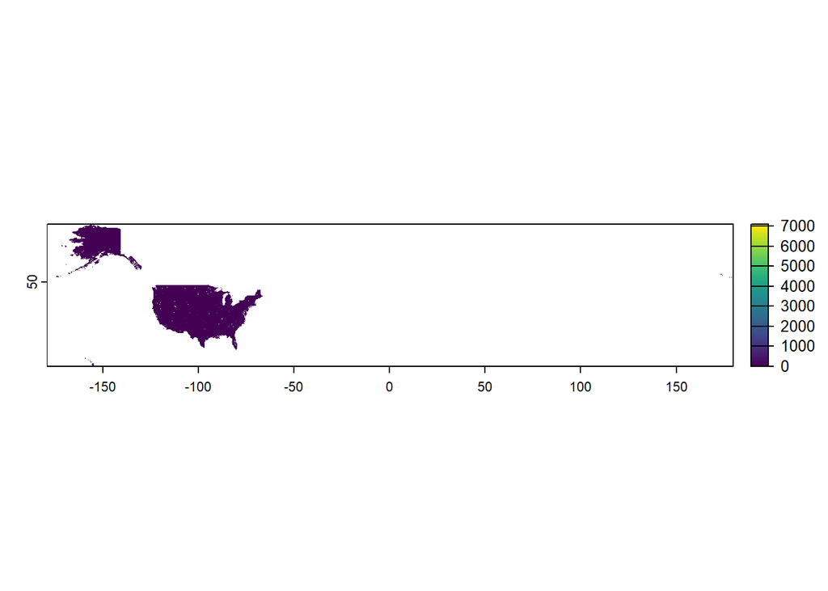

**✅ Solution 2**

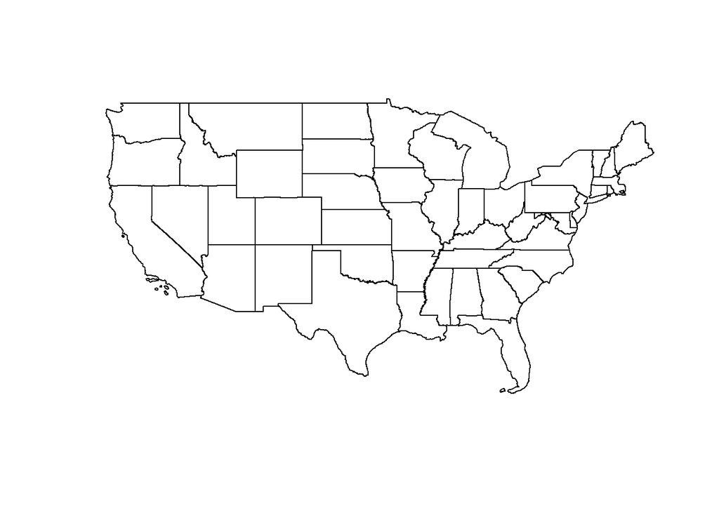

```r
# install.packages("tigris")
library(tigris)
# Load the states and filter out non-contiguous territories
US_states <- states(progress_bar=FALSE) |>
  dplyr::filter(!STUSPS %in% c("AK", "AS", "GU", "HI", "MP", "PR", "VI"))
plot(sf::st_geometry(US_states))
```

**✅ Solution 3**

```r
bbox <- sf::st_bbox(US_states) |>
  sf::st_as_sfc() |>
  sf::st_transform(crs = terra::crs(USA_pop_2020))

USA_pop_2020 <- terra::crop(
  USA_pop_2020,
  bbox
)
```

**✅ Solution 4**

```r
USA_pop_2020 <- terra::project(USA_pop_2020, "EPSG:5070")
US_states <- sf::st_transform(US_states, crs = "EPSG:5070")
```

**✅ Solution 5**

```
<SpatRaster> resampled to 501095 cells.
```

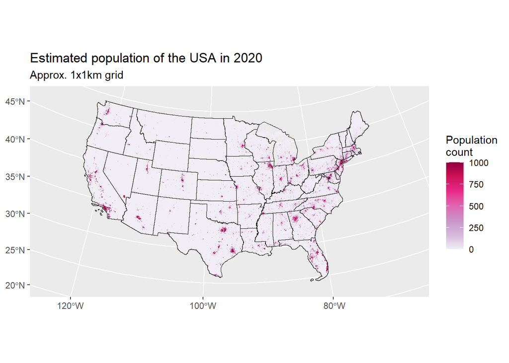

```r
ggplot()+
  tidyterra::geom_spatraster(data = USA_pop_2020)+
  geom_sf(data = US_states,
          fill = "transparent",
          color = "black",
          size = 5) +
  scale_fill_distiller(type = "seq",
                       palette = "PuRd",
                       direction = 1,
                       na.value = "transparent",
                       limits = c(0, 1000),
                       oob = scales::squish
                       ) +
  labs(
    fill = "Population\ncount",
    title = "Estimated population of the USA in 2020",
    subtitle = "Approx. 1x1km grid"
  )
```